# Discussion 3

2025-09-26

## Review notes

For each of the data frames, descriptive stats, and data vis chapters we covered this past week, if you haven’t already, read through the additional notes in the examples and run some of them for more R practice (no need to show work for this)

- Show an example below in an R chunk for each of the following:
  1. Find an example online of a TSV and an XLSX data set and read them in, then make sure all columns are properly parsed/converted and print out the data frame (if you’re having difficult finding one, you can create one yourself too)
  2. Practice using the data frame subsetting operations, in particular practice both the $ syntax as well as the [row, col] syntax.
  3. Practice finding and interpreting the summary statistics demonstrated, including all the different center/spread statistics.
  4. Pick one additional summary statistic in the “Other measures” sections to read about on your own, then write a brief summary on it, including its definition, its main use cases, and give a brief demo of how to compute it in R.
  5. Review the different plot types covered, and practice each of them on a dataset of your choice.
  6. Consult the ggplot2 help pages & cheat sheet, pick 1 additional aesthetic to incorporate into a plot, explain what it is and how it works, give an example of its use, and discuss its usefulness/appropriateness in various plotting contexts.

```r
  library(e1071)
    library(readxl)
    library(tidyverse)


titanic_tsv <- read_tsv("titanic-parquet.tsv")
titanic_tsv$Age <- as.numeric(titanic_tsv$Age)
seattle_xlsx <- read_excel("seattleWeather.xlsx")

str(titanic_tsv)
```

```
## spc_tbl_ [891 × 12] (S3: spec_tbl_df/tbl_df/tbl/data.frame)
##  $ PassengerId: num [1:891] 1 2 3 4 5 6 7 8 9 10 ...
##  $ Survived   : num [1:891] 0 1 1 1 0 0 0 0 1 1 ...
##  $ Pclass     : num [1:891] 3 1 3 1 3 3 1 3 3 2 ...
##  $ Name       : chr [1:891] "Braund, Mr. Owen Harris" "Cumings, Mrs. John Bradley (Florence Briggs Thayer)" "Heikkinen, Miss. Laina" "Futrelle, Mrs. Jacques Heath (Lily May Peel)" ...
##  $ Sex        : chr [1:891] "male" "female" "female" "female" ...
##  $ Age        : num [1:891] 22 38 26 35 35 NA 54 2 27 14 ...
##  $ SibSp      : num [1:891] 1 1 0 1 0 0 0 3 0 1 ...
##  $ Parch      : num [1:891] 0 0 0 0 0 0 0 1 2 0 ...
##  $ Ticket     : chr [1:891] "A/5 21171" "PC 17599" "STON/O2. 3101282" "113803" ...
##  $ Fare       : num [1:891] 7.25 71.28 7.92 53.1 8.05 ...
##  $ Cabin      : chr [1:891] "\\N" "C85" "\\N" "C123" ...
##  $ Embarked   : chr [1:891] "S" "C" "S" "S" ...
##  - attr(*, "spec")=
##   .. cols(
##   ..   PassengerId = col_double(),
##   ..   Survived = col_double(),
##   ..   Pclass = col_double(),
##   ..   Name = col_character(),
##   ..   Sex = col_character(),
##   ..   Age = col_character(),
##   ..   SibSp = col_double(),
##   ..   Parch = col_double(),
##   ..   Ticket = col_character(),
##   ..   Fare = col_double(),
##   ..   Cabin = col_character(),
##   ..   Embarked = col_character()
##   .. )
##  - attr(*, "problems")=<externalptr>
```

```r
seattle_xlsx
```

```
## # A tibble: 1,461 × 6
##    date                precipitation temp_max temp_min  wind weather
##    <dttm>                      <dbl>    <dbl>    <dbl> <dbl> <chr>
##  1 2012-01-01 00:00:00           0       12.8      5     4.7 drizzle
##  2 2012-01-02 00:00:00          10.9     10.6      2.8   4.5 rain
##  3 2012-01-03 00:00:00           0.8     11.7      7.2   2.3 rain
##  4 2012-01-04 00:00:00          20.3     12.2      5.6   4.7 rain
##  5 2012-01-05 00:00:00           1.3      8.9      2.8   6.1 rain
##  6 2012-01-06 00:00:00           2.5      4.4      2.2   2.2 rain
##  7 2012-01-07 00:00:00           0        7.2      2.8   2.3 rain
##  8 2012-01-08 00:00:00           0       10        2.8   2   sun
##  9 2012-01-09 00:00:00           4.3      9.4      5     3.4 rain
## 10 2012-01-10 00:00:00           1        6.1      0.6   3.4 rain
## # ℹ 1,451 more rows
```

```r
print(head(titanic_tsv))
```

```
## # A tibble: 6 × 12
##   PassengerId Survived Pclass Name    Sex     Age SibSp Parch Ticket  Fare Cabin
##         <dbl>    <dbl>  <dbl> <chr>   <chr> <dbl> <dbl> <dbl> <chr>  <dbl> <chr>
## 1           1        0      3 Braund… male     22     1     0 A/5 2…  7.25 "\\N"
## 2           2        1      1 Cuming… fema…    38     1     0 PC 17… 71.3  "C85"
## 3           3        1      3 Heikki… fema…    26     0     0 STON/…  7.92 "\\N"
## 4           4        1      1 Futrel… fema…    35     1     0 113803 53.1  "C12…
## 5           5        0      3 Allen,… male     35     0     0 373450  8.05 "\\N"
## 6           6        0      3 Moran,… male     NA     0     0 330877  8.46 "\\N"
## # ℹ 1 more variable: Embarked <chr>
```

```r
ages <- titanic_tsv$Age
print(ages)
```

```
##   [1] 22.00 38.00 26.00 35.00 35.00    NA 54.00  2.00 27.00 14.00  4.00 58.00
##  [13] 20.00 39.00 14.00 55.00  2.00    NA 31.00    NA 35.00 34.00 15.00 28.00
##  [25]  8.00 38.00    NA 19.00    NA    NA 40.00    NA    NA 66.00 28.00 42.00
##  [37]    NA 21.00 18.00 14.00 40.00 27.00    NA  3.00 19.00    NA    NA    NA
##  [49]    NA 18.00  7.00 21.00 49.00 29.00 65.00    NA 21.00 28.50  5.00 11.00
##  [61] 22.00 38.00 45.00  4.00    NA    NA 29.00 19.00 17.00 26.00 32.00 16.00
##  [73] 21.00 26.00 32.00 25.00    NA    NA  0.83 30.00 22.00 29.00    NA 28.00
##  [85] 17.00 33.00 16.00    NA 23.00 24.00 29.00 20.00 46.00 26.00 59.00    NA
##  [97] 71.00 23.00 34.00 34.00 28.00    NA 21.00 33.00 37.00 28.00 21.00    NA
## [109] 38.00    NA 47.00 14.50 22.00 20.00 17.00 21.00 70.50 29.00 24.00  2.00
## [121] 21.00    NA 32.50 32.50 54.00 12.00    NA 24.00    NA 45.00 33.00 20.00
## [133] 47.00 29.00 25.00 23.00 19.00 37.00 16.00 24.00    NA 22.00 24.00 19.00
## [145] 18.00 19.00 27.00  9.00 36.50 42.00 51.00 22.00 55.50 40.50    NA 51.00
## [157] 16.00 30.00    NA    NA 44.00 40.00 26.00 17.00  1.00  9.00    NA 45.00
## [169]    NA 28.00 61.00  4.00  1.00 21.00 56.00 18.00    NA 50.00 30.00 36.00
```

[output cut: 60 more lines]

```r
# extracted the first 5 rows, survived and sex

subset_df <- titanic_tsv[1:5, c("Survived", "Sex")]
print(subset_df)
```

```
## # A tibble: 5 × 2
##   Survived Sex
##      <dbl> <chr>
## 1        0 male
## 2        1 female
## 3        1 female
## 4        1 female
## 5        0 male
```

```r
#extracting a specific value: PassangerClass for first row:

pclass_first <- titanic_tsv[1, "Pclass"]
print(pclass_first)
```

```
## # A tibble: 1 × 1
##   Pclass
##    <dbl>
## 1      3
```

```r
# Summary statistics on Age column (centers: mean, median; spreads: sd, IQR, range)


age_mean <- mean(titanic_tsv$Age, na.rm = TRUE)
age_mean
```

```
## [1] 29.69912
```

```r
age_median <- median(titanic_tsv$Age, na.rm = TRUE)
age_median
```

```
## [1] 28
```

```r
age_sd <- sd(titanic_tsv$Age, na.rm = TRUE)
age_sd
```

```
## [1] 14.5265
```

```r
age_iqr <- IQR(titanic_tsv$Age, na.rm = TRUE)
age_iqr
```

```
## [1] 17.875
```

```r
age_range <- range(titanic_tsv$Age, na.rm = TRUE)
age_range
```

```
## [1]  0.42 80.00
```

```r
age_summary <- summary(titanic_tsv$Age)
age_range
```

```
## [1]  0.42 80.00
```

```r
# Print out statistics
cat("Mean:", age_mean, "\n")
```

```
## Mean: 29.69912
```

```r
cat("Median:", age_median, "\n")
```

```
## Median: 28
```

```r
cat("Standard deviation:", age_sd, "\n")
```

```
## Standard deviation: 14.5265
```

```r
cat("IQR:", age_iqr, "\n")
```

```
## IQR: 17.875
```

```r
cat("Range:", age_range, "\n")
```

```
## Range: 0.42 80
```

```r
print(age_summary)
```

```
##    Min. 1st Qu.  Median    Mean 3rd Qu.    Max.    NA's
##    0.42   20.12   28.00   29.70   38.00   80.00     177
```

```r
# picking a summary statistic
#Were going to do skewness, which measures the asymmety of a distribution around its mean.

# Fix: Convert Age to numeric first to handle any text values
titanic_tsv$Age <- as.numeric(titanic_tsv$Age)

age_skewness <- skewness(titanic_tsv$Age, na.rm = TRUE)

#concatinating
cat("Skewness of Age:", age_skewness, "\n")
```

```
## Skewness of Age: 0.3874744
```

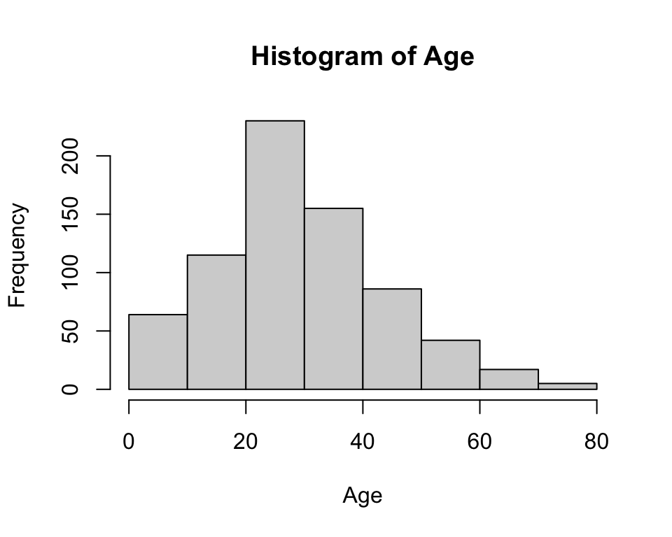

```r
#5 different type of plot demonstrations

#making a histogram
hist(titanic_tsv$Age, main = "Histogram of Age", xlab = "Age")
```

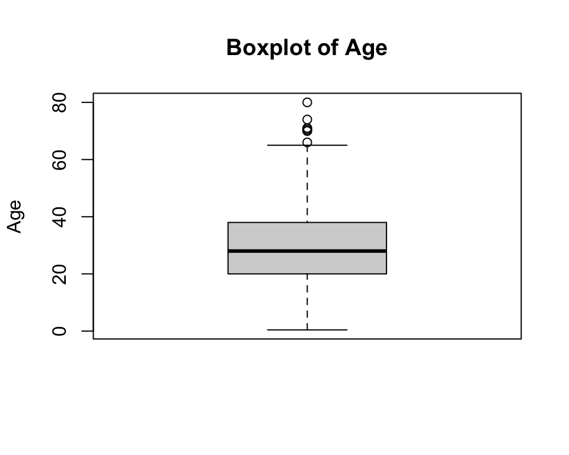

```r
#making a boxplot :
boxplot(titanic_tsv$Age, main = "Boxplot of Age", ylab = "Age")
```

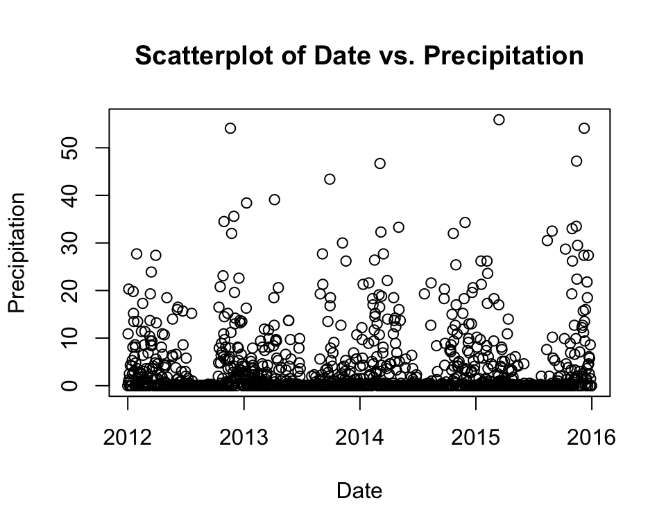

```r
# doing a scatterplot: come back to this

plot(seattle_xlsx$date, seattle_xlsx$precipitation,
     main = "Scatterplot of Date vs. Precipitation",
     xlab = "Date", ylab = "Precipitation")
```

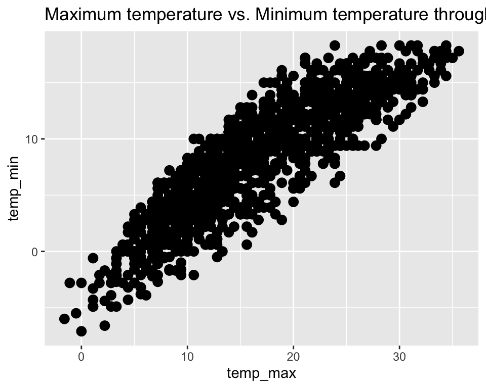

```r
#6

ggplot(seattle_xlsx, aes(x = temp_max, y = temp_min)) +
  geom_point(size = 3) +
  labs(title = "Maximum temperature vs. Minimum temperature through 2012-2015")
```